# Mean Variance Relationships

Brett Engelmann

Tuesday, November 10, 2015

# Overview

Is this relationship driven by biology or by a confounding relationship between peptide intensity and silac ratios?

## Packages Used

```r
require(gplots)
require(RColorBrewer)
require(plyr)
require(dplyr)
require(reshape2)
require(qdapRegex)
require(ggplot2)
require(Hmisc)
require(MASS)
require(limma)
require(swamp)
```

## A protein expression phosphopeptide variability relationship?

There is a positive correlation between protein expression and phosphosite variability. **Spoiler alert**. This is may be driven in part by the positive correlation between replicate precision and peptide intensity. That is, the s.d. of replicate measurements decreases with increasing peptide intensity. Note there is no such relationship for the SILAC ratios themselves.

```
## [1] 0.05184077
```

```
## [1] 0.003082246
```

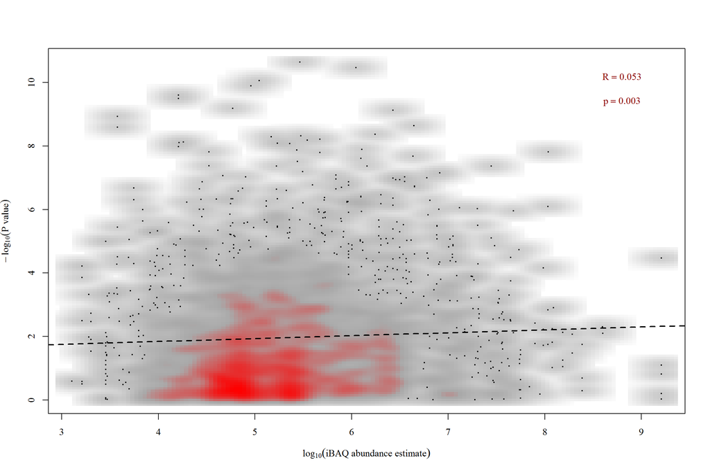

## A phosphosite ‘density’ phosphopeptide variability relationship?

There is a slight depletion for proteins with higher ‘densities’ (#phosphosites/unit protein length) in diffphos. Proteins that are highly connected (hubs) tend to have higher phosphorylation density.

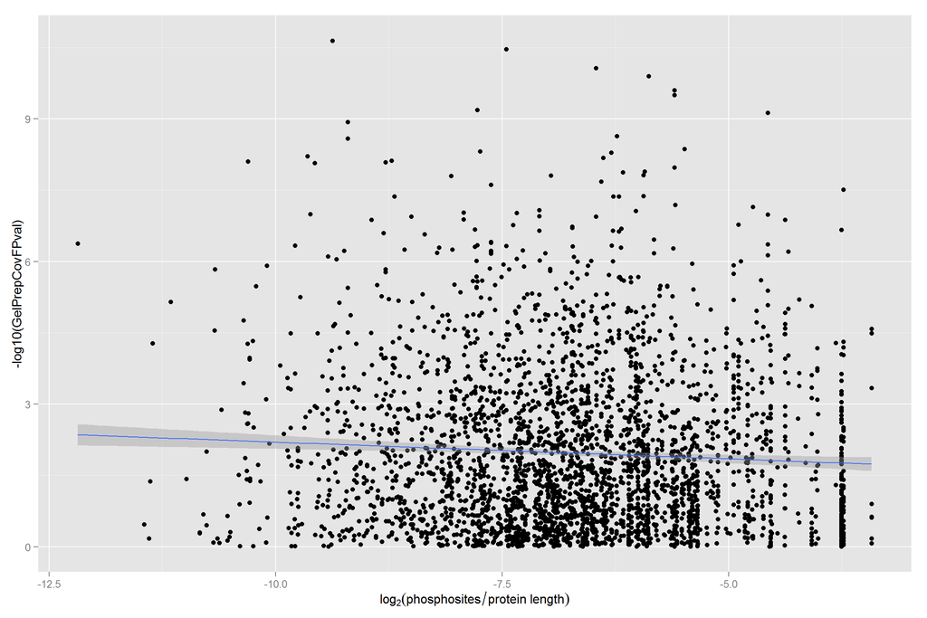

This number of sites/unit length measurement should control for the fact that longer proteins are expressed at lower levels. If we used simply the number of sites/protein this effect would dominate and would therefore drive a depletion.

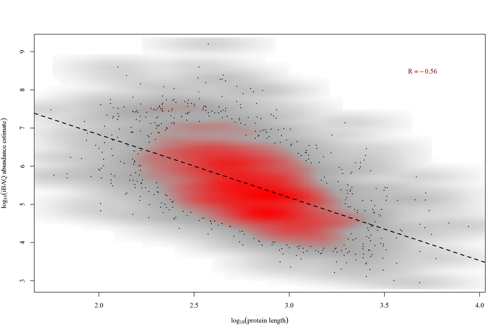

```r
x <- log10(MajProtID.length.expression$length)
y <- log10(MajProtID.length.expression$expression)
smoothScatter(x,y, nbin = 150, bandwidth = 0.1,
              cex = .3,
              pch = 19, nrpoints = .15*length(ibaq$GelPrepCovFPval),
              colramp = colorRampPalette(c("white", "light gray", "dark gray", "red")),
              xlab = expression(log[10](protein~length)),
              ylab = expression(log[10](iBAQ~abundance~estimate)), lwd = 10,
              family = "serif"
)
reg.line <- lm(y~x, na.action = "na.omit")
abline(reg.line, lwd = 2, lty = 2)
text(3.7, 8.5, expression(R == -0.56), col = "darkred", cex = 1, family = "serif") # rsquared and pvalue
```

However we still observe a concentration dependent effect, where lowly expressed proteins drive the depletion. This again could be explained by the lower precision of estimates derived from lowly expressed proteins (see below).

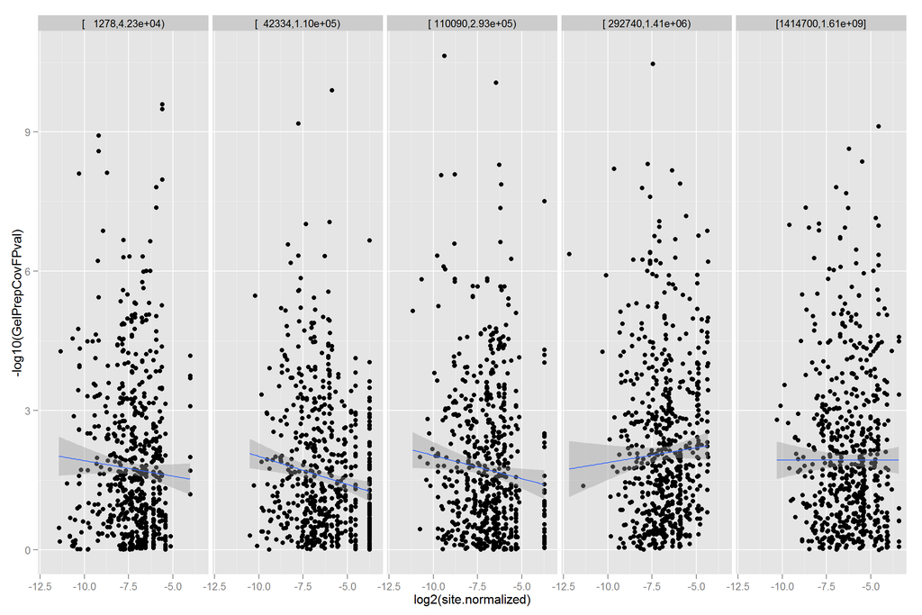

```r
site.variation.normalized.concentration <- ggplot(ibaq.sites.subtoDE, aes(x = log2(site.normalized),
                                                            y = -log10(GelPrepCovFPval))) +
  geom_point() +
  facet_grid(.~Ibaqquintile) +
  geom_smooth(method = "rlm")
site.variation.normalized.concentration
```

# Mean Variance Relationship Investigation

For the observed relationship to be valid, The SILAC ratios should not have increased variability with increased peptide intensity. This would manifest in MA plots as a broadening of the blob at the high peptide intensity end.

## MA plots of silac ratios vs peptide intensity

There is no relationship between peptide intensity and SILAC ratio

[output not shown]

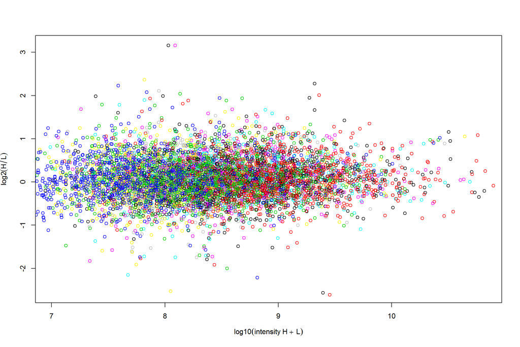

```r
#MA plots of intensity and protein group level SILAC ratios
for (i in 1:12) {
  if(i == 1) plot(log10(complete[, i + 12]), complete[, i], xlab = expression(log10(intensity~H~+~L)), ylab = expression(log2(H/L)))
  else points(log10(complete[, i + 12]), complete[, i], col = i)
    }
```

There is no mean variance relationship for the ratios

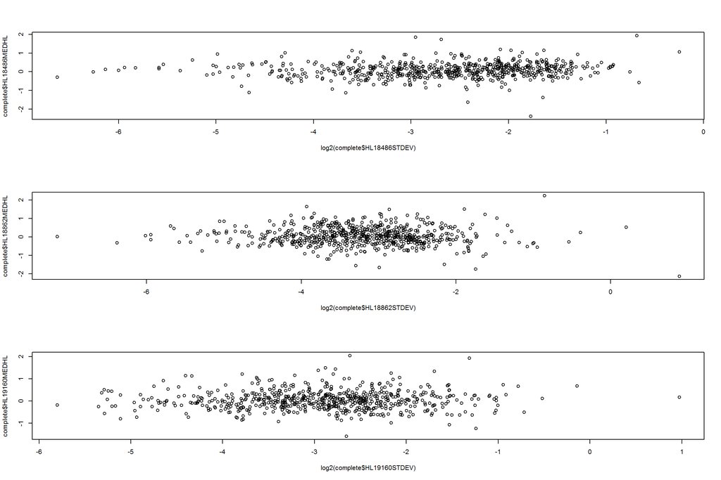

```r
par(mfrow = c(3,1))
plot(log2(complete$HL18486STDEV), complete$HL18486MEDHL)
plot(log2(complete$HL18862STDEV), complete$HL18862MEDHL)
plot(log2(complete$HL19160STDEV), complete$HL19160MEDHL)
```

## SILAC ratio replicate variance inverse related to phosphopeptide intensity

However, there **is** a relationship between phosphopeptide intensity/iBAQ and SILAC ratio variance. Higher intensity derived ratios are more precise. This would lead to an improvement in power to detect diffphos for highly expressed proteins/high intensity derived peptide ratios.

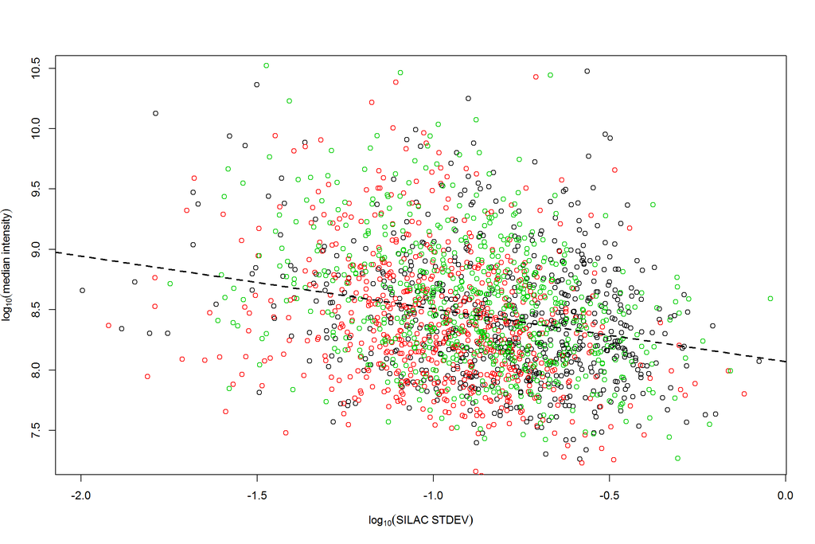

```r
plot(log10(complete$HL18486STDEV), log10(complete$HL18486MEDINT), ylab = expression(log[10](median~intensity)), xlab = expression(log[10](SILAC~STDEV)))
reg.line <- lm( log10(complete$HL18486MEDINT) ~ log10(complete$HL18486STDEV), na.action = "na.omit")
points(log10(complete$HL18862STDEV), log10(complete$HL18862MEDINT), col = 2)
points(log10(complete$HL19160STDEV), log10(complete$HL19160MEDINT), col = 3)
abline(reg.line, col = 1, lty =2, lwd = 2)
```

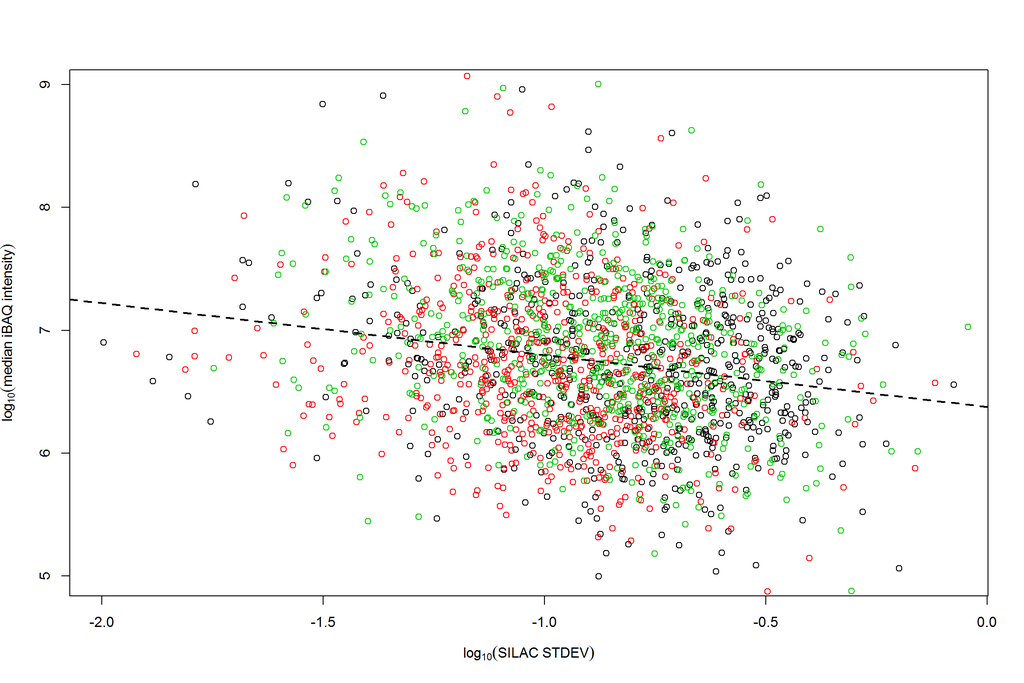

```r
#this relationship is also apparent for the ibaq values
plot(log10(complete$HL18486STDEV), log10(complete$HL18486MEDiBAQ), ylab = expression(log[10](median~iBAQ~intensity)), xlab = expression(log[10](SILAC~STDEV)))
points(log10(complete$HL18862STDEV), log10(complete$HL18862MEDiBAQ), col = 2)
points(log10(complete$HL19160STDEV), log10(complete$HL19160MEDiBAQ), col = 3)
reg.line <- lm( log10(complete$HL18486MEDiBAQ) ~ log10(complete$HL18486STDEV), na.action = "na.omit")
abline(reg.line, col = 1, lty =2, lwd = 2)
```

# Can anything be done?

As of now I am removing **all** of my protein level enrichment analysis based on annotations that may be confounded with differences in protein length or expression level.